# Homework 11

CHUEH-JU KUO

2026-02-16

## Instructions

Answer the following questions and complete the exercises in RMarkdown. Please embed all of your code and push your final work to your repository. Your final lab report should be organized, clean, and run free from errors. Remember, you must remove the `#` for the included code chunks to run. Be sure to add your name to the author header above. For any included plots, make sure they are clearly labeled. You are free to use any plot type that you feel best communicates the results of your analysis.

Make sure to use the formatting conventions of RMarkdown to make your report neat and clean!

## Load the libraries

```r
library(tidyverse)
library(janitor)
```

```r
options(scipen = 999)
```

## Data

For this homework, we are going to use the [Gapminder](https://www.gapminder.org/data/) data on population (pop), GDP per capita (gdp), and life expectancy (lex). These data were downloaded and compiled using the `gapminder_compile.Rmd` script in the data folder.

Let’s focus our attention on data from the past 100 years, between 1925 and 2025.

```r
gapminder <- read_csv("data/gapminder.csv") %>%
  clean_names() %>%
  filter(between(year, 1925, 2025))
```

1. Use the function(s) of your choice to get an idea of the overall structure of the data, including its dimensions, column names, classes, etc.

```r
glimpse(gapminder)
```

```
## Rows: 19,695
## Columns: 5
## $ country <chr> "Afghanistan", "Afghanistan", "Afghanistan", "Afghanistan", "A…
## $ year    <dbl> 1925, 1926, 1927, 1928, 1929, 1930, 1931, 1932, 1933, 1934, 19…
## $ pop     <dbl> 8748779, 8289705, 7854721, 7442562, 7121951, 6888085, 6736411,…
## $ gdp     <dbl> 1113.793, 1127.866, 1142.117, 1156.548, 1171.161, 1185.959, 12…
## $ lex     <dbl> 38.87, 39.01, 39.16, 39.30, 39.44, 39.59, 39.73, 39.88, 40.02,…
```

```r
summary(gapminder)
```

```
##    country               year           pop                  gdp
##  Length:19695       Min.   :1925   Min.   :       651   Min.   :   316.1
##  Class :character   1st Qu.:1950   1st Qu.:    741871   1st Qu.:  2124.1
##  Mode  :character   Median :1975   Median :   3915338   Median :  4661.2
##                     Mean   :1975   Mean   :  22712317   Mean   : 12053.8
##                     3rd Qu.:2000   3rd Qu.:  12044477   3rd Qu.: 13082.4
##                     Max.   :2025   Max.   :1463865525   Max.   :475911.3
##                                    NA's   :25           NA's   :202
##       lex
##  Min.   : 4.18
##  1st Qu.:48.13
##  Median :61.91
##  Mean   :59.17
##  3rd Qu.:70.89
##  Max.   :85.63
##  NA's   :357
```

2. How many countries are represented in this dataset? There are 195 countries.

```r
n_distinct(gapminder$country)
```

```
## [1] 195
```

3. Which five countries have had the largest absolute population growth between 1925-2025? Show this as a table. The top five country is India, China, Indonesia, Pakistan and USA

```r
gapminder %>%
  filter(year %in% c(1925, 2025))%>%
  select(country, year, pop)%>%
  pivot_wider(names_from = year,
              values_from = pop,
              names_prefix = "pop_")%>%
  group_by(country)%>%
  mutate(ppl_grwoth_absolute=pop_2025-pop_1925)%>%
  arrange(desc(ppl_grwoth_absolute))
```

```
## # A tibble: 195 × 4
## # Groups:   country [195]
##    country     pop_1925   pop_2025 ppl_grwoth_absolute
##    <chr>          <dbl>      <dbl>               <dbl>
##  1 India      304406019 1463865525          1159459506
##  2 China      473741473 1416096094           942354621
##  3 Indonesia   49685263  285721236           236035973
##  4 Pakistan    22624808  255219554           232594746
##  5 USA        116193761  347275807           231082046
##  6 Nigeria     24779607  237527782           212748175
##  7 Brazil      30241952  212812405           182570453
##  8 Bangladesh  30286950  175686899           145399949
##  9 Ethiopia    17437296  135472051           118034755
## 10 Mexico      15509333  131946900           116437567
## # ℹ 185 more rows
```

4. Make a plot that shows population growth over time for the top country you found in question #3.

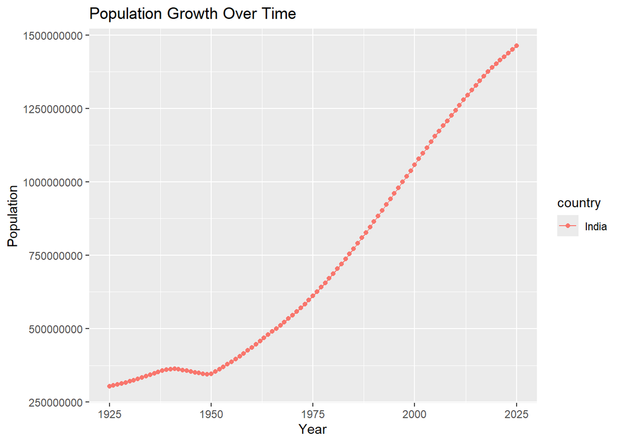

```r
gapminder %>%
  filter((year>=1925 &year<=2025)&country=="India")%>%
  ggplot(aes(x=year, y=pop, color=country))+
  geom_point()+
  geom_line()+
  labs(title="Population Growth Over Time",
       x="Year",
       y="Population")
```

```r
#note for myself:
#if you want to draw the line for top five country the code will be like this
#gapminder %>%
#  filter((year>=1925 &year<=2025)&country%in%c("India", "China", "Indonesia", "Pakistan", "USA"))%>%
#  ggplot(aes(x=year, y=pop, color=country))+
#  geom_point()+
#  geom_line()+
#  labs(title="Population Growth Over Time", x="Year", y="Population Growth Over Time")
```

5. Has global life expectancy changed between 1925 and 2025? Show the min, median, mean, and max for all countries (combined) in the dataset.

```r
gapminder %>%
  filter(year %in% c(1925, 2025))%>%
  group_by(year)%>%
  summarize(min_lex=min(lex, na.rm=T),
         max_lex=max(lex, na.rm=T),
         mean_lex=mean(lex, na.rm=T),
         median_lex=median(lex, na.rm=T))
```

```
## # A tibble: 2 × 5
##    year min_lex max_lex mean_lex median_lex
##   <dbl>   <dbl>   <dbl>    <dbl>      <dbl>
## 1  1925    21.0    63.5     38.1       35.9
## 2  2025    52.8    85.6     73.9       74.8
```

6. Make a plot that shows the distribution of life expectancy for all countries in 1925 and 2025 (try using `geom_density`). What do you notice about the shift in life expectancy over time? Life expectancy of all country is shifted from number around 30 to 70 for 2025. This indicated the increment of life spans of human.

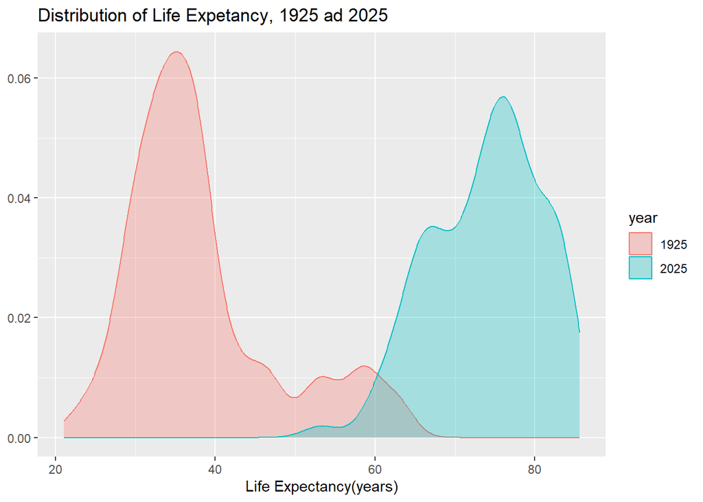

```r
gapminder %>%
  filter(year %in% c(1925, 2025))%>%
  mutate(year=factor(year))%>%
  ggplot(aes(x=lex, fill=year, color=year))+
  geom_density(alpha=0.3)+
  labs(title="Distribution of Life Expetancy, 1925 ad 2025",
       x="Life Expectancy(years)",
       y=NULL,
       color="year",
       fill="year")
```

7. We are interested in the relationship between per capita GDP and life expectancy; i.e. does having more money help you live longer in 2025? Show this as a plot. (Suggestion! Remove Monaco as an extreme outlier.) I think more money does help you live longer in 2025 since the graph have a positive trend line.

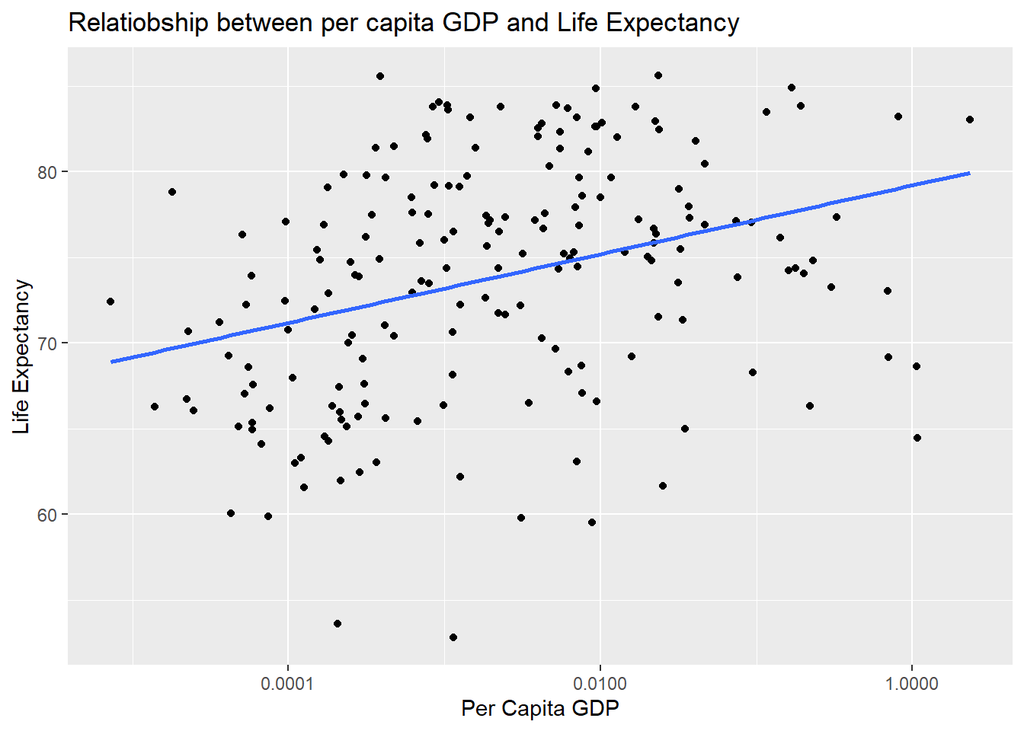

```r
gapminder %>%
  filter(year==2025& country != "Monaco")%>%
  mutate(capita_gdp=gdp/pop)%>%
  ggplot(aes(x=capita_gdp, y=lex))+
  geom_point()+geom_smooth(method = "lm", se = FALSE)+
  scale_x_log10()+
  labs(title="Relatiobship between per capita GDP and Life Expectancy",
       x="Per Capita GDP",
       y="Life Expectancy")
```

```r
gapminder %>%
  filter(year %in% c(1975, 2025) & country != "Monaco")%>%
  mutate(capita_gdp=gdp/pop)%>%
  select(country, year, capita_gdp) %>%
  pivot_wider(names_from = year,
              values_from = capita_gdp,
              names_prefix = "capita_gdp_")%>%
  group_by(country)%>%
  mutate(abs_capita_gdp=capita_gdp_2025-capita_gdp_1975)%>%
  arrange(desc(abs_capita_gdp))
```

```
## # A tibble: 194 × 4
## # Groups:   country [194]
##    country                        capita_gdp_1975 capita_gdp_2025 abs_capita_gdp
##    <chr>                                    <dbl>           <dbl>          <dbl>
##  1 St. Kitts and Nevis                     0.118            0.696          0.578
##  2 San Marino                              2.01             2.33           0.319
##  3 Dominica                                0.0482           0.303          0.255
##  4 Antigua and Barbuda                     0.117            0.328          0.211
##  5 St. Vincent and the Grenadines          0.0310           0.201          0.170
##  6 Tuvalu                                  0.556            0.699          0.143
##  7 Seychelles                              0.0964           0.232          0.136
##  8 Grenada                                 0.0374           0.160          0.123
##  9 St. Lucia                               0.0353           0.142          0.106
## 10 Luxembourg                              0.0875           0.193          0.105
## # ℹ 184 more rows
```

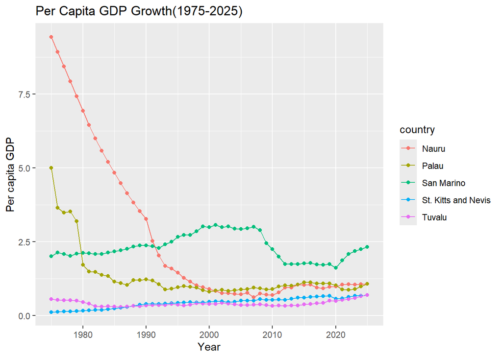

```r
gapminder %>%
  filter((year>=1975 &year<=2025)&country%in%c("San Marino", "Palau", "St. Kitts and Nevis", "Tuvalu", "Nauru"))%>%
  mutate(capita_gdp=gdp/pop)%>%
  ggplot(aes(x=year, y=capita_gdp, color=country))+
  geom_point()+
  geom_line()+
  labs(title="Per Capita GDP Growth(1975-2025)", x="Year", y="Per capita GDP")
```

10. Do one analysis of your choice that includes a table and plot as outputs. How is the life expectancy and GDP per capita of Germany change around 1945(end of world war 2) to 1965?

```r
gapminder %>%
  filter(between(year, 1945, 1965), country == "Germany") %>%
  mutate(capita_gdp = gdp/pop) %>%
  select(year, lex, capita_gdp) %>%
  pivot_longer(col=c(lex, capita_gdp), names_to = "type", values_to = "value")
```

```
## # A tibble: 42 × 3
##     year type            value
##    <dbl> <chr>           <dbl>
##  1  1945 lex        28.8
##  2  1945 capita_gdp  0.000133
##  3  1946 lex        60.2
##  4  1946 capita_gdp  0.0000653
##  5  1947 lex        61.8
##  6  1947 capita_gdp  0.0000716
##  7  1948 lex        63.3
##  8  1948 capita_gdp  0.0000830
##  9  1949 lex        64.9
## 10  1949 capita_gdp  0.0000957
## # ℹ 32 more rows
```

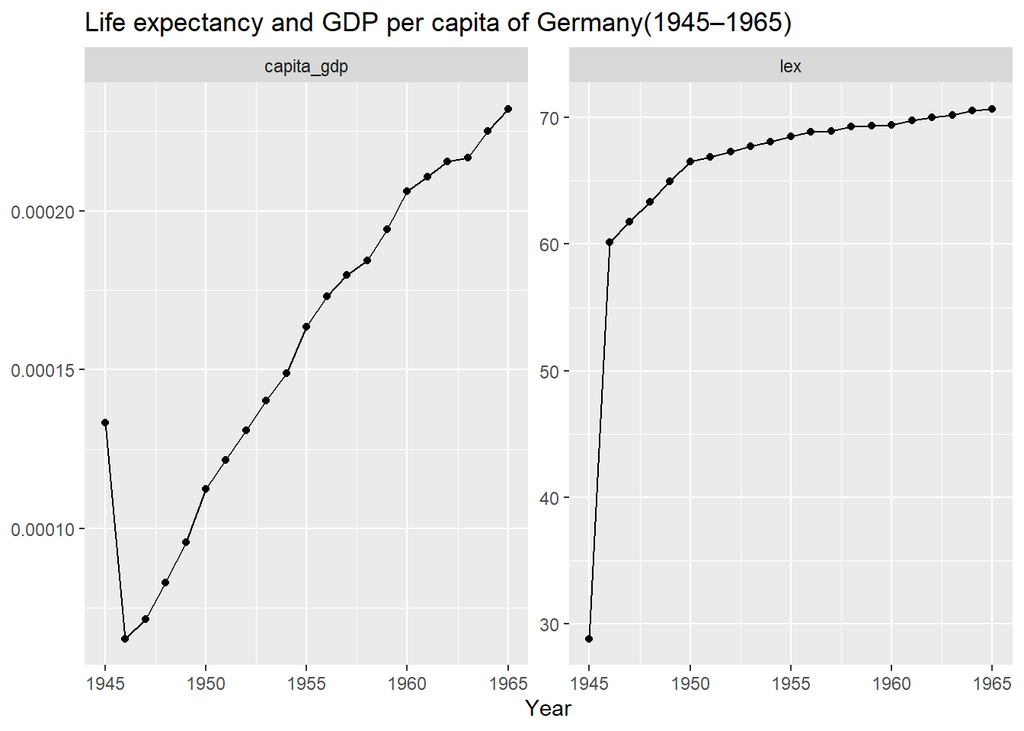

```r
gapminder %>%
  filter(between(year, 1945, 1965), country == "Germany") %>%
  mutate(capita_gdp = gdp/pop) %>%
  select(year, lex, capita_gdp) %>%
  pivot_longer(cols=c(lex, capita_gdp),
               names_to = "type",
               values_to = "value") %>%
  ggplot(aes(x=year, y=value))+
  geom_line() +
  geom_point() +
  facet_wrap(~ type,scales = "free_y", ncol =2) + #free y means each graph have itw own y
  labs(title = "Life expectancy and GDP per capita of Germany(1945–1965)",
       x = "Year",
       y = NULL)
```

## Knit and Upload Please knit your work as an .html file and upload to Canvas. Homework is due before the start of the next lab. No late work is accepted. Make sure to use the formatting conventions of RMarkdown to make your report neat and clean!